# Name: Sergiy Goloviatinski

# Assignment 3 ATML 2020

## Unsupervised Feature Learning and Transfer Learning

In many real world applications the amount of labelled training data will be very limited since it is expensive to obtain. Often you will have access to a large amount of unlabelled data however. In this assignment you will explore techniques to leverage large amounts of unlabelled data to learn image representations. These image representations can then be used for novel tasks (e.g., classification) via supervised transfer learning. If the number of labelled examples for the target task is small, unsupervised feature learning can substatially improve the performance on the target task.

### Data

In this assignment you are given two types of training sets:

- **A large unlabelled training set:** This data will be used to learn a data representation with some unsupervised feature learning method of your choice.
- **A small labelled training set:** This data will be used to perform transfer learning where the previously learned representation is repurposed for image classification.

### Choose an Unsupervised Learning Task

You are free to choose any method to learn features in an unsupervised manner. Possible examples are:

- **Autoencoders:** You can learn features in the encoder of some variant of autoencoders (DAE, VAE, etc...).
- **GAN:** You can use generative adversarial training and transfer features of the discriminator.
- **Self-Supervised Learning:** You can use a pretext task where labels come "for free". Some simple examples are "Rotation Prediction" and "Examplar-CNN".

## Task 1: Prepare data for unsupervised pre-training, supervised transfer learning and evaluation

You should create four different datasets:

1. unlabelled training set (optionally including self-supervised labels)
2. labelled training set
3. labelled validation set
4. unlabelled test set (kaggle)

```python
try:
    from google.colab import drive
    import sys
    drive.mount('/content/drive',force_remount=True)
    drive_folder = '/content/drive/My Drive/unine/cours/adv_ml/Assignment/Ass3/'
    sys.path.append(drive_folder)
    zip_path = drive_folder+'data_assignment3.zip'
    !cp "{zip_path}" .
    !unzip -q data_assignment3.zip
except:
    pass

train_unlabelled_dir = 'data_assignment3/train_unlabelled'
train_dir = 'data_assignment3/train'
val_dir = 'data_assignment3/val'
test_dir = 'data_assignment3/test'
```

[output not shown]

```python
from __future__ import print_function
import torch
from PIL import Image
import glob
import torch.utils.data as data
from tqdm.notebook import trange, tqdm

class LabelledImages(data.Dataset):
    """Labelled images dataset."""

    def __init__(self, root_dir, transform=None,data_limit=None):

        if transform:
            self.transform = transform

        flatten = lambda l: [item for sublist in l for item in sublist]
        files = flatten([glob.glob(e) for e in [root_dir+'/[0-9]/*.jpg',root_dir+'/[0-9][0-9]/*.jpg',root_dir+'/[0-9][0-9][0-9]/*.jpg']])

        self.images=[]
        self.labels=[]

        if data_limit:
            files=files[:data_limit]

        for file in tqdm(files):
            temp = Image.open(file)
            keep = temp.copy()
            self.labels.append(int(file.split('/')[-2]))
            self.images.append(keep)
            temp.close()

    def __len__(self):

        return len(self.images)

    def __getitem__(self, idx):

        label = self.labels[idx]
        image = self.images[idx]

        if self.transform:
            image = self.transform(image)

        return image,label

class UnlabelledImages(torch.utils.data.Dataset):
    def __init__(self, root_dir, transform=None,data_limit=None):
        self.transform=transform
        files=glob.glob(root_dir+'/*.jpg')
        self.images=[]
        if data_limit:
            files=files[:data_limit]
        for file in tqdm(files):
            temp = Image.open(file)
            keep = temp.copy()
            self.images.append(keep)
            temp.close()

    def __getitem__(self, index):
        image=self.images[index]
        if self.transform:
            image=self.transform(image)
        return image

    def __len__(self):
        return len(self.images)
```

```python
from torchvision.transforms import ToTensor, Normalize, Compose, Resize, RandomHorizontalFlip, ColorJitter,RandomCrop

transform = Compose([Resize((64, 64)),
                    ToTensor(), # Converts to Tensor, scales to [0, 1] float (from [0, 255] int)
                    Normalize(mean=(0.5, 0.5, 0.5,), std=(0.5, 0.5, 0.5)), # scales to [-1.0, 1.0]
                      ])

train_transform = Compose([RandomCrop((64, 64)),
                        RandomHorizontalFlip(),
                        ColorJitter(0.3,0.7),
                        ToTensor(), # Converts to Tensor, scales to [0, 1] float (from [0, 255] int)
                        Normalize(mean=(0.5, 0.5, 0.5,), std=(0.5, 0.5, 0.5)), # scales to [-1.0, 1.0]
                        ])

train_set = LabelledImages(train_dir,transform=train_transform)
val_set = LabelledImages(val_dir,transform=transform)
unlabelled_train_set=UnlabelledImages(train_unlabelled_dir,transform=transform)
test_set=UnlabelledImages(test_dir,transform=transform)
```

## Task 2: Define the CNN architecture

The architecture should be designed such that the first $k$ layers (the backbone) of the network are identical during unsupervised pre-training and supervised transfer learning. The remaining layers (the network head) can be different for unsupervised and supervised training.

Example: If you choose to train an autoencoder, the encoder layers would be shared between unsupervised pre-training and supervised transfer. The decoder layers would be removed and replaced by some number of fully-connected layers during transfer to classification.

```python
import torch.nn as nn

class ConvNet(nn.Module):

    def __init__(self,num_classes=200):
        super(ConvNet, self).__init__()
        self.conv_layers = nn.Sequential(
            nn.Conv2d(3, 64, kernel_size=4, stride=2, padding=1, bias=False),
            nn.LeakyReLU(0.2, inplace=True),
            nn.Conv2d(64, 128,  kernel_size=4, stride=2, padding=1, bias=False),
            nn.BatchNorm2d(128),
            nn.LeakyReLU(0.2, inplace=True),
            nn.Conv2d(128, 256,  kernel_size=4, stride=2, padding=1, bias=False),
            nn.BatchNorm2d(256),
            nn.LeakyReLU(0.2, inplace=True),
            nn.Conv2d(256, 256,  kernel_size=3, stride=1, padding=1, bias=False),
            nn.BatchNorm2d(256),
            nn.LeakyReLU(0.2, inplace=True),
            nn.Conv2d(256, 256,  kernel_size=3, stride=1, padding=1, bias=False),
            nn.BatchNorm2d(256),
            nn.LeakyReLU(0.2, inplace=True),
            nn.Conv2d(256, 512,  kernel_size=4, stride=2, padding=1, bias=False),
            nn.LeakyReLU(0.2, inplace=True),
        )

        self.linear_layers = nn.Sequential(
            nn.Linear(8192, 2048),
            nn.LeakyReLU(0.2, inplace=True),
            nn.Dropout(),
            nn.Linear(2048, num_classes)
        )


    def forward(self, input):
        output = self.conv_layers(input)
        output = torch.flatten(output, 1)
        output = self.linear_layers(output)
        return output
```

## Task 3. Unsupervised Pre-Training

Implement the unsupervised training code for your model. You are not allowed to use a pre-trained model or labelled data (must train from scratch on the unlabelled training set). Monitor the performance on the pre-training task to check for convergence. Save the network parameters after pre-training (you will need them during transfer experiments).

```python
import torch.nn.functional as F
nz=200


class Generator(nn.Module):
    """DCGAN Generator."""
    def __init__(self, z_dim=nz, num_filters=64):
        super(Generator, self).__init__()
        self.z_dim = z_dim
        self.num_filters = num_filters

        # 1 x 1 -> 4 x 4
        self.deconv1 = nn.ConvTranspose2d(
            in_channels=z_dim, out_channels=num_filters * 8,
            kernel_size=(4, 4), bias=False
        )
        self.bn1 = nn.BatchNorm2d(num_filters * 8)

        # 4 x 4 -> 8 x 8
        self.deconv2 = nn.ConvTranspose2d(
            in_channels=num_filters * 8, out_channels=num_filters * 4,
            kernel_size=(4, 4), stride=2, padding=1, bias=False,
        )
        self.bn2 = nn.BatchNorm2d(num_filters * 4)

        # 8 x 8 -> 16 x 16
        self.deconv3 = nn.ConvTranspose2d(
            in_channels=num_filters * 4, out_channels=num_filters * 2,
            kernel_size=(4, 4), stride=2, padding=1, bias=False,
        )
        self.bn3 = nn.BatchNorm2d(num_filters*2)

        # 16 x 16 -> 32 x 32
        self.deconv4 = nn.ConvTranspose2d(
            in_channels=num_filters * 2, out_channels=num_filters ,
            kernel_size=(4, 4), stride=2, padding=1, bias=False,
        )

        self.bn4 = nn.BatchNorm2d(num_filters)


        # 32 x 32 -> 64 x 64
        self.deconv5 = nn.ConvTranspose2d(
            in_channels=num_filters , out_channels=3 ,
            kernel_size=(4, 4), stride=2, padding=1, bias=False,
        )


    def forward(self, x):
        x = F.relu(self.bn1(self.deconv1(x)))
        x = F.relu(self.bn2(self.deconv2(x)))
        x = F.relu(self.bn3(self.deconv3(x)))
        x = F.relu(self.bn4(self.deconv4(x)))
        return torch.tanh(self.deconv5(x))
```

```python
class Discriminator(nn.Module):
    """DCGAN Discriminator."""
    def __init__(self,num_classes=1):
        super(Discriminator, self).__init__()
        self.conv_layers = nn.Sequential(
            nn.Conv2d(3, 64, kernel_size=4, stride=2, padding=1, bias=False),
            nn.LeakyReLU(0.2, inplace=True),
            nn.Conv2d(64, 128,  kernel_size=4, stride=2, padding=1, bias=False),
            nn.BatchNorm2d(128),
            nn.LeakyReLU(0.2, inplace=True),
            nn.Conv2d(128, 256,  kernel_size=4, stride=2, padding=1, bias=False),
            nn.BatchNorm2d(256),
            nn.LeakyReLU(0.2, inplace=True),
            nn.Conv2d(256, 256,  kernel_size=3, stride=1, padding=1, bias=False),
            nn.BatchNorm2d(256),
            nn.LeakyReLU(0.2, inplace=True),
            nn.Conv2d(256, 256,  kernel_size=3, stride=1, padding=1, bias=False),
            nn.BatchNorm2d(256),
            nn.LeakyReLU(0.2, inplace=True),
            nn.Conv2d(256, 512,  kernel_size=4, stride=2, padding=1, bias=False),
            nn.LeakyReLU(0.2, inplace=True),
        )

        self.linear_layers = nn.Sequential(
            nn.Linear(8192, num_classes)
        )


    def forward(self, input):
        output = self.conv_layers(input)
        output = torch.flatten(output, 1)
        output = self.linear_layers(output)
        output = nn.Sigmoid()(output)
        return output
```

```python
# Decide which device we want to run on
device = torch.device("cuda:0" if torch.cuda.is_available() else "cpu")
```

```python
netG = Generator()
netD = Discriminator()

if torch.cuda.is_available():
    netG=netG.cuda()
    netD=netD.cuda()
```

```python
trainloader = torch.utils.data.DataLoader(unlabelled_train_set, batch_size=64, shuffle=True, num_workers=8,pin_memory=True)
```

```python
# custom weights initialization called on netG and netD
def weights_init(m):
    classname = m.__class__.__name__
    if classname.find('Conv') != -1:
        nn.init.normal_(m.weight.data, 0.0, 0.02)
    elif classname.find('BatchNorm') != -1:
        nn.init.normal_(m.weight.data, 1.0, 0.02)
        nn.init.constant_(m.bias.data, 0)

netG.apply(weights_init)
netD.apply(weights_init)
```

```
Discriminator(
  (conv_layers): Sequential(
    (0): Conv2d(3, 64, kernel_size=(4, 4), stride=(2, 2), padding=(1, 1), bias=False)
    (1): LeakyReLU(negative_slope=0.2, inplace=True)
    (2): Conv2d(64, 128, kernel_size=(4, 4), stride=(2, 2), padding=(1, 1), bias=False)
    (3): BatchNorm2d(128, eps=1e-05, momentum=0.1, affine=True, track_running_stats=True)
    (4): LeakyReLU(negative_slope=0.2, inplace=True)
    (5): Conv2d(128, 256, kernel_size=(4, 4), stride=(2, 2), padding=(1, 1), bias=False)
    (6): BatchNorm2d(256, eps=1e-05, momentum=0.1, affine=True, track_running_stats=True)
    (7): LeakyReLU(negative_slope=0.2, inplace=True)
    (8): Conv2d(256, 256, kernel_size=(3, 3), stride=(1, 1), padding=(1, 1), bias=False)
    (9): BatchNorm2d(256, eps=1e-05, momentum=0.1, affine=True, track_running_stats=True)
    (10): LeakyReLU(negative_slope=0.2, inplace=True)
    (11): Conv2d(256, 256, kernel_size=(3, 3), stride=(1, 1), padding=(1, 1), bias=False)
    (12): BatchNorm2d(256, eps=1e-05, momentum=0.1, affine=True, track_running_stats=True)
    (13): LeakyReLU(negative_slope=0.2, inplace=True)
    (14): Conv2d(256, 512, kernel_size=(4, 4), stride=(2, 2), padding=(1, 1), bias=False)
    (15): LeakyReLU(negative_slope=0.2, inplace=True)
  )
  (linear_layers): Sequential(
    (0): Linear(in_features=8192, out_features=1, bias=True)
  )
)
```

```python
import torch.optim as optim

lr=2e-4
# Beta1 hyperparam for Adam optimizers
beta1 = 0.5

# Initialize BCELoss function
criterion = nn.BCELoss()

# Create batch of latent vectors that we will use to visualize
#  the progression of the generator
fixed_noise = torch.randn(64, nz, 1, 1, device=device)

# Setup Adam optimizers for both G and D
optimizerD = optim.Adam(netD.parameters(), lr=lr, betas=(beta1, 0.999))
optimizerG = optim.Adam(netG.parameters(), lr=lr, betas=(beta1, 0.999))
```

```python
def generate_labels(fake=False):
    #real labels are between 0.9 and 1, fake labels between 0 and 0.1 and there are 5% of labels that are permuted
    if fake:
        label_f = torch.rand(int(b_size*0.95)+1, device=device)
        label_r = torch.rand(int(b_size*0.05), device=device)
    else:
        label_f = torch.rand(int(b_size*0.05), device=device)
        label_r = torch.rand(int(b_size*0.95)+1, device=device)
    label_f/=10
    label_r=1-label_r/10
    label=torch.cat((label_f,label_r),0)
    # shuffle the tensor:
    tensor_rand_idx = torch.randperm(label.nelement())
    label = label.view(-1)[tensor_rand_idx].view(label.size())
    return label.unsqueeze(1)
```

```python
import torchvision.utils as vutils
import copy

# Lists to keep track of progress
img_list = []
G_losses = []
D_losses = []
iters = 0

num_epochs=5
min_loss=9999
best_D_state_dict=None

print("Starting Training Loop...")
# For each epoch
for epoch in tqdm(range(num_epochs)):
    # For each batch in the dataloader
    for i, data in tqdm(enumerate(trainloader, 0),total=len(trainloader)):

        ############################
        # (1) Update D network: maximize log(D(x)) + log(1 - D(G(z)))
        ###########################
        ## Train with all-real batch
        netD.zero_grad()
        # Format batch
        real_cpu = data.to(device)
        b_size = real_cpu.size(0)
        # real label between 0.9 and 1
        label = generate_labels(fake=False)
        # Forward pass real batch through D
        output = netD(real_cpu)
        # Calculate loss on all-real batch
        errD_real = criterion(output, label)
        # Calculate gradients for D in backward pass
        errD_real.backward()
        D_x = output.mean().item()
        ## Train with all-fake batch
        # Generate batch of latent vectors
        noise = torch.randn(b_size, nz, 1, 1, device=device)
        # Generate fake image batch with G
        fake = netG(noise)
        label = generate_labels(fake=True)
        # Classify all fake batch with D
        output = netD(fake.detach())
        # Calculate D's loss on the all-fake batch
        errD_fake = criterion(output, label)
        # Calculate the gradients for this batch
        errD_fake.backward()
        D_G_z1 = output.mean().item()
        # Add the gradients from the all-real and all-fake batches
        errD = errD_real + errD_fake
        # Update D
        optimizerD.step()

        ############################
        # (2) Update G network: maximize log(D(G(z)))
        ###########################
        netG.zero_grad()
        label = generate_labels(fake=False)  # fake labels are real for generator cost
        # Since we just updated D, perform another forward pass of all-fake batch through D
        output = netD(fake)

        # Calculate G's loss based on this output
        errG = criterion(output, label)
        # Calculate gradients for G
        errG.backward()
        D_G_z2 = output.mean().item()
        # Update G
        optimizerG.step()

        # Output training stats
        if i % 50 == 0:
            print('[%d/%d][%d/%d]\tLoss_D: %.4f\tLoss_G: %.4f\tD(x): %.4f\tD(G(z)): %.4f / %.4f'
                  % (epoch+1, num_epochs, i, len(trainloader),
                     errD.item(), errG.item(), D_x, D_G_z1, D_G_z2))

        # Save Losses for plotting later
        G_losses.append(errG.item())
        D_losses.append(errD.item())

        if D_x < min_loss and epoch==num_epochs-1:
            min_loss=D_x
            best_D_state_dict=copy.deepcopy(netD.state_dict())

        # Check how the generator is doing by saving G's output on fixed_noise
        if (iters % 500 == 0) or ((epoch == num_epochs-1) and (i == len(trainloader)-1)):
            with torch.no_grad():
                fake = netG(fixed_noise).detach().cpu()
            img_list.append(vutils.make_grid(fake, padding=2, normalize=True))

        iters += 1
print(f'min_loss= {min_loss}')
```

```
Starting Training Loop...
```

```
[1/5][0/1563]	Loss_D: 1.3318	Loss_G: 2.5950	D(x): 0.5138	D(G(z)): 0.4795 / 0.0634
[1/5][50/1563]	Loss_D: 0.6831	Loss_G: 3.3724	D(x): 0.8626	D(G(z)): 0.1324 / 0.0254
[1/5][100/1563]	Loss_D: 0.6379	Loss_G: 2.7018	D(x): 0.8738	D(G(z)): 0.0494 / 0.0516
[1/5][150/1563]	Loss_D: 0.6747	Loss_G: 2.6839	D(x): 0.8660	D(G(z)): 0.1230 / 0.0514
[1/5][200/1563]	Loss_D: 0.7014	Loss_G: 2.7190	D(x): 0.7688	D(G(z)): 0.0999 / 0.0545
[1/5][250/1563]	Loss_D: 0.6890	Loss_G: 2.8368	D(x): 0.8913	D(G(z)): 0.2236 / 0.0468
[1/5][300/1563]	Loss_D: 0.8151	Loss_G: 2.7567	D(x): 0.7918	D(G(z)): 0.2639 / 0.0570
[1/5][350/1563]	Loss_D: 0.9238	Loss_G: 2.3483	D(x): 0.7804	D(G(z)): 0.3660 / 0.0934
[1/5][400/1563]	Loss_D: 0.8569	Loss_G: 2.4275	D(x): 0.7888	D(G(z)): 0.2404 / 0.0812
[1/5][450/1563]	Loss_D: 0.7680	Loss_G: 1.8838	D(x): 0.7180	D(G(z)): 0.0952 / 0.1379
[1/5][500/1563]	Loss_D: 1.0879	Loss_G: 5.1224	D(x): 0.8274	D(G(z)): 0.4512 / 0.0046
[1/5][550/1563]	Loss_D: 0.7538	Loss_G: 2.4696	D(x): 0.7745	D(G(z)): 0.1889 / 0.0791
[1/5][600/1563]	Loss_D: 0.8522	Loss_G: 4.0353	D(x): 0.8972	D(G(z)): 0.3831 / 0.0141
[1/5][650/1563]	Loss_D: 0.9093	Loss_G: 1.4817	D(x): 0.5989	D(G(z)): 0.1414 / 0.2295
[1/5][700/1563]	Loss_D: 0.7683	Loss_G: 2.8400	D(x): 0.8942	D(G(z)): 0.2832 / 0.0507
[1/5][750/1563]	Loss_D: 0.6995	Loss_G: 2.6308	D(x): 0.8561	D(G(z)): 0.2245 / 0.0632
[1/5][800/1563]	Loss_D: 0.9950	Loss_G: 3.8363	D(x): 0.8632	D(G(z)): 0.4554 / 0.0157
[1/5][850/1563]	Loss_D: 0.8645	Loss_G: 1.7131	D(x): 0.7167	D(G(z)): 0.2643 / 0.1658
[1/5][900/1563]	Loss_D: 0.9032	Loss_G: 3.3554	D(x): 0.8649	D(G(z)): 0.3373 / 0.0278
[1/5][950/1563]	Loss_D: 0.8710	Loss_G: 1.8002	D(x): 0.6847	D(G(z)): 0.1868 / 0.1518
[1/5][1000/1563]	Loss_D: 0.8006	Loss_G: 2.1178	D(x): 0.8040	D(G(z)): 0.2078 / 0.1101
[1/5][1050/1563]	Loss_D: 0.8306	Loss_G: 3.3732	D(x): 0.8926	D(G(z)): 0.2862 / 0.0276
[1/5][1100/1563]	Loss_D: 0.8145	Loss_G: 4.3095	D(x): 0.9190	D(G(z)): 0.3550 / 0.0108
[1/5][1150/1563]	Loss_D: 1.2045	Loss_G: 3.7001	D(x): 0.9019	D(G(z)): 0.5771 / 0.0220
[1/5][1200/1563]	Loss_D: 0.8893	Loss_G: 1.9052	D(x): 0.6694	D(G(z)): 0.1677 / 0.1386
[1/5][1250/1563]	Loss_D: 0.8845	Loss_G: 2.3545	D(x): 0.8770	D(G(z)): 0.3638 / 0.0823
[1/5][1300/1563]	Loss_D: 0.7892	Loss_G: 2.0921	D(x): 0.8149	D(G(z)): 0.2916 / 0.1133
[1/5][1350/1563]	Loss_D: 0.9551	Loss_G: 1.6984	D(x): 0.5872	D(G(z)): 0.1351 / 0.1667
[1/5][1400/1563]	Loss_D: 2.4465	Loss_G: 2.1064	D(x): 0.1516	D(G(z)): 0.0079 / 0.1137
[1/5][1450/1563]	Loss_D: 1.0494	Loss_G: 1.4007	D(x): 0.5612	D(G(z)): 0.2138 / 0.2432
[1/5][1500/1563]	Loss_D: 1.0272	Loss_G: 2.5282	D(x): 0.6985	D(G(z)): 0.3849 / 0.0722
[1/5][1550/1563]	Loss_D: 1.6308	Loss_G: 0.8157	D(x): 0.3053	D(G(z)): 0.0497 / 0.4432
```

```
[2/5][0/1563]	Loss_D: 0.9306	Loss_G: 2.0949	D(x): 0.6649	D(G(z)): 0.1312 / 0.1157
[2/5][50/1563]	Loss_D: 0.9609	Loss_G: 2.0215	D(x): 0.8858	D(G(z)): 0.3916 / 0.1253
[2/5][100/1563]	Loss_D: 0.7863	Loss_G: 2.0629	D(x): 0.7667	D(G(z)): 0.2541 / 0.1234
[2/5][150/1563]	Loss_D: 0.8297	Loss_G: 2.8628	D(x): 0.8381	D(G(z)): 0.3147 / 0.0574
[2/5][200/1563]	Loss_D: 0.7486	Loss_G: 2.5897	D(x): 0.8885	D(G(z)): 0.2286 / 0.0670
[2/5][250/1563]	Loss_D: 0.8915	Loss_G: 1.3088	D(x): 0.6635	D(G(z)): 0.1501 / 0.2689
[2/5][300/1563]	Loss_D: 0.8625	Loss_G: 1.9105	D(x): 0.6696	D(G(z)): 0.1108 / 0.1460
[2/5][350/1563]	Loss_D: 0.7786	Loss_G: 2.4474	D(x): 0.7464	D(G(z)): 0.1652 / 0.0905
[2/5][400/1563]	Loss_D: 0.8987	Loss_G: 2.4812	D(x): 0.9163	D(G(z)): 0.3668 / 0.0809
[2/5][450/1563]	Loss_D: 0.7471	Loss_G: 2.2552	D(x): 0.7954	D(G(z)): 0.1055 / 0.1047
[2/5][500/1563]	Loss_D: 0.8743	Loss_G: 2.1512	D(x): 0.7605	D(G(z)): 0.3025 / 0.1072
[2/5][550/1563]	Loss_D: 0.8049	Loss_G: 2.0804	D(x): 0.7806	D(G(z)): 0.2426 / 0.1201
[2/5][600/1563]	Loss_D: 0.8556	Loss_G: 2.6981	D(x): 0.8098	D(G(z)): 0.3033 / 0.0634
[2/5][650/1563]	Loss_D: 0.9051	Loss_G: 1.7231	D(x): 0.6715	D(G(z)): 0.2642 / 0.1707
[2/5][700/1563]	Loss_D: 0.9514	Loss_G: 1.7948	D(x): 0.5925	D(G(z)): 0.0913 / 0.1681
[2/5][750/1563]	Loss_D: 0.9939	Loss_G: 3.6493	D(x): 0.9323	D(G(z)): 0.4250 / 0.0255
[2/5][800/1563]	Loss_D: 1.0030	Loss_G: 2.4846	D(x): 0.5939	D(G(z)): 0.0848 / 0.0851
[2/5][850/1563]	Loss_D: 1.0301	Loss_G: 1.7691	D(x): 0.5606	D(G(z)): 0.0557 / 0.1699
[2/5][900/1563]	Loss_D: 0.7963	Loss_G: 1.7232	D(x): 0.7957	D(G(z)): 0.2552 / 0.1705
[2/5][950/1563]	Loss_D: 1.1077	Loss_G: 1.3536	D(x): 0.5494	D(G(z)): 0.0843 / 0.2746
[2/5][1000/1563]	Loss_D: 0.7674	Loss_G: 2.4081	D(x): 0.7509	D(G(z)): 0.1580 / 0.0889
[2/5][1050/1563]	Loss_D: 0.7519	Loss_G: 2.0045	D(x): 0.7749	D(G(z)): 0.1866 / 0.1393
[2/5][1100/1563]	Loss_D: 0.6907	Loss_G: 2.3889	D(x): 0.8797	D(G(z)): 0.1396 / 0.1000
[2/5][1150/1563]	Loss_D: 1.2780	Loss_G: 1.2308	D(x): 0.4620	D(G(z)): 0.0632 / 0.3107
[2/5][1200/1563]	Loss_D: 0.9893	Loss_G: 3.3450	D(x): 0.9078	D(G(z)): 0.4106 / 0.0296
[2/5][1250/1563]	Loss_D: 0.8914	Loss_G: 2.1072	D(x): 0.8142	D(G(z)): 0.3305 / 0.1228
[2/5][1300/1563]	Loss_D: 0.9295	Loss_G: 1.3483	D(x): 0.6153	D(G(z)): 0.1097 / 0.2759
[2/5][1350/1563]	Loss_D: 0.7162	Loss_G: 2.5881	D(x): 0.8404	D(G(z)): 0.2053 / 0.0675
[2/5][1400/1563]	Loss_D: 0.7143	Loss_G: 2.5140	D(x): 0.8134	D(G(z)): 0.0792 / 0.0836
[2/5][1450/1563]	Loss_D: 0.9290	Loss_G: 1.5957	D(x): 0.5976	D(G(z)): 0.0850 / 0.2359
[2/5][1500/1563]	Loss_D: 0.8834	Loss_G: 2.3678	D(x): 0.6721	D(G(z)): 0.1290 / 0.0927
[2/5][1550/1563]	Loss_D: 1.1023	Loss_G: 1.1863	D(x): 0.5487	D(G(z)): 0.1034 / 0.3220
```

```
[3/5][0/1563]	Loss_D: 1.0932	Loss_G: 2.1574	D(x): 0.5138	D(G(z)): 0.0457 / 0.1278
[3/5][50/1563]	Loss_D: 0.7963	Loss_G: 1.4550	D(x): 0.8063	D(G(z)): 0.2635 / 0.2402
[3/5][100/1563]	Loss_D: 0.8319	Loss_G: 1.2448	D(x): 0.6856	D(G(z)): 0.1527 / 0.2879
[3/5][150/1563]	Loss_D: 1.0102	Loss_G: 1.6306	D(x): 0.8841	D(G(z)): 0.4389 / 0.1980
[3/5][200/1563]	Loss_D: 0.7787	Loss_G: 2.1822	D(x): 0.7340	D(G(z)): 0.1873 / 0.1008
[3/5][250/1563]	Loss_D: 1.0945	Loss_G: 1.3709	D(x): 0.5359	D(G(z)): 0.0863 / 0.2485
[3/5][300/1563]	Loss_D: 1.0641	Loss_G: 3.6559	D(x): 0.8866	D(G(z)): 0.4635 / 0.0217
[3/5][350/1563]	Loss_D: 0.9004	Loss_G: 1.8186	D(x): 0.6714	D(G(z)): 0.1726 / 0.1644
[3/5][400/1563]	Loss_D: 1.1003	Loss_G: 0.6704	D(x): 0.4652	D(G(z)): 0.0949 / 0.5595
[3/5][450/1563]	Loss_D: 0.8127	Loss_G: 2.2385	D(x): 0.7651	D(G(z)): 0.2217 / 0.1014
[3/5][500/1563]	Loss_D: 0.8375	Loss_G: 2.7774	D(x): 0.9132	D(G(z)): 0.3344 / 0.0583
[3/5][550/1563]	Loss_D: 0.9536	Loss_G: 1.7572	D(x): 0.6175	D(G(z)): 0.0989 / 0.1697
[3/5][600/1563]	Loss_D: 0.9689	Loss_G: 1.5263	D(x): 0.6784	D(G(z)): 0.2105 / 0.2053
[3/5][650/1563]	Loss_D: 1.3114	Loss_G: 3.1742	D(x): 0.8700	D(G(z)): 0.5610 / 0.0365
[3/5][700/1563]	Loss_D: 0.8976	Loss_G: 1.4962	D(x): 0.6767	D(G(z)): 0.1829 / 0.2160
[3/5][750/1563]	Loss_D: 0.9969	Loss_G: 1.6055	D(x): 0.6574	D(G(z)): 0.2994 / 0.1990
[3/5][800/1563]	Loss_D: 0.8983	Loss_G: 1.9879	D(x): 0.6980	D(G(z)): 0.2028 / 0.1263
[3/5][850/1563]	Loss_D: 1.1795	Loss_G: 2.4596	D(x): 0.8539	D(G(z)): 0.5052 / 0.0856
[3/5][900/1563]	Loss_D: 1.3577	Loss_G: 3.4563	D(x): 0.9402	D(G(z)): 0.6550 / 0.0257
[3/5][950/1563]	Loss_D: 0.9693	Loss_G: 1.4325	D(x): 0.5894	D(G(z)): 0.1096 / 0.2430
[3/5][1000/1563]	Loss_D: 1.4775	Loss_G: 0.5344	D(x): 0.3451	D(G(z)): 0.0627 / 0.6385
[3/5][1050/1563]	Loss_D: 0.8599	Loss_G: 1.4857	D(x): 0.6583	D(G(z)): 0.1773 / 0.2131
[3/5][1100/1563]	Loss_D: 0.7644	Loss_G: 2.1851	D(x): 0.8099	D(G(z)): 0.2221 / 0.1030
[3/5][1150/1563]	Loss_D: 0.7544	Loss_G: 2.2716	D(x): 0.8444	D(G(z)): 0.2590 / 0.0964
[3/5][1200/1563]	Loss_D: 0.9580	Loss_G: 2.3408	D(x): 0.9210	D(G(z)): 0.3971 / 0.0896
[3/5][1250/1563]	Loss_D: 0.8424	Loss_G: 1.8016	D(x): 0.7303	D(G(z)): 0.2209 / 0.1602
[3/5][1300/1563]	Loss_D: 1.1997	Loss_G: 4.9901	D(x): 0.9460	D(G(z)): 0.5227 / 0.0058
[3/5][1350/1563]	Loss_D: 0.9419	Loss_G: 2.2900	D(x): 0.7268	D(G(z)): 0.3069 / 0.0932
[3/5][1400/1563]	Loss_D: 0.6616	Loss_G: 2.6457	D(x): 0.8312	D(G(z)): 0.1387 / 0.0644
[3/5][1450/1563]	Loss_D: 0.9046	Loss_G: 2.2489	D(x): 0.8285	D(G(z)): 0.3838 / 0.0939
[3/5][1500/1563]	Loss_D: 0.8473	Loss_G: 1.3670	D(x): 0.7201	D(G(z)): 0.2126 / 0.2496
[3/5][1550/1563]	Loss_D: 1.0092	Loss_G: 1.1600	D(x): 0.5793	D(G(z)): 0.1084 / 0.3235
```

```
[4/5][0/1563]	Loss_D: 0.8644	Loss_G: 1.8466	D(x): 0.7013	D(G(z)): 0.1386 / 0.1527
[4/5][50/1563]	Loss_D: 1.2490	Loss_G: 2.1530	D(x): 0.4452	D(G(z)): 0.0304 / 0.1196
[4/5][100/1563]	Loss_D: 1.2073	Loss_G: 4.2442	D(x): 0.9773	D(G(z)): 0.5551 / 0.0112
[4/5][150/1563]	Loss_D: 0.8903	Loss_G: 1.2851	D(x): 0.6388	D(G(z)): 0.1698 / 0.2749
[4/5][200/1563]	Loss_D: 0.7084	Loss_G: 2.4215	D(x): 0.8835	D(G(z)): 0.1310 / 0.0856
[4/5][250/1563]	Loss_D: 0.9693	Loss_G: 3.2358	D(x): 0.8004	D(G(z)): 0.3863 / 0.0367
[4/5][300/1563]	Loss_D: 1.1192	Loss_G: 3.2343	D(x): 0.9433	D(G(z)): 0.4775 / 0.0357
[4/5][350/1563]	Loss_D: 0.8105	Loss_G: 2.3575	D(x): 0.8399	D(G(z)): 0.3211 / 0.0907
[4/5][400/1563]	Loss_D: 0.7288	Loss_G: 2.7291	D(x): 0.8870	D(G(z)): 0.2060 / 0.0583
[4/5][450/1563]	Loss_D: 0.8817	Loss_G: 1.2903	D(x): 0.8184	D(G(z)): 0.3142 / 0.2854
[4/5][500/1563]	Loss_D: 1.1309	Loss_G: 3.3381	D(x): 0.8967	D(G(z)): 0.4646 / 0.0312
[4/5][550/1563]	Loss_D: 0.8094	Loss_G: 1.3930	D(x): 0.6940	D(G(z)): 0.1215 / 0.2530
[4/5][600/1563]	Loss_D: 0.8418	Loss_G: 1.6897	D(x): 0.7604	D(G(z)): 0.2544 / 0.1895
[4/5][650/1563]	Loss_D: 3.8521	Loss_G: 4.2746	D(x): 0.9933	D(G(z)): 0.9641 / 0.0129
[4/5][700/1563]	Loss_D: 0.8124	Loss_G: 2.1789	D(x): 0.7863	D(G(z)): 0.2246 / 0.1046
[4/5][750/1563]	Loss_D: 0.7499	Loss_G: 2.2002	D(x): 0.8669	D(G(z)): 0.2099 / 0.1116
[4/5][800/1563]	Loss_D: 1.1635	Loss_G: 0.7301	D(x): 0.4729	D(G(z)): 0.0581 / 0.5296
[4/5][850/1563]	Loss_D: 1.0072	Loss_G: 1.8430	D(x): 0.5574	D(G(z)): 0.0589 / 0.1570
[4/5][900/1563]	Loss_D: 0.7406	Loss_G: 3.1659	D(x): 0.9238	D(G(z)): 0.2373 / 0.0434
[4/5][950/1563]	Loss_D: 1.1902	Loss_G: 1.2455	D(x): 0.4645	D(G(z)): 0.0479 / 0.3085
[4/5][1000/1563]	Loss_D: 0.9525	Loss_G: 1.7395	D(x): 0.7414	D(G(z)): 0.3322 / 0.1726
[4/5][1050/1563]	Loss_D: 0.6743	Loss_G: 2.1067	D(x): 0.8211	D(G(z)): 0.1336 / 0.1238
[4/5][1100/1563]	Loss_D: 0.7967	Loss_G: 2.0433	D(x): 0.7584	D(G(z)): 0.1559 / 0.1264
[4/5][1150/1563]	Loss_D: 0.7367	Loss_G: 2.8977	D(x): 0.8695	D(G(z)): 0.1974 / 0.0515
[4/5][1200/1563]	Loss_D: 0.8040	Loss_G: 1.1465	D(x): 0.6814	D(G(z)): 0.1572 / 0.3190
[4/5][1250/1563]	Loss_D: 0.7974	Loss_G: 2.0090	D(x): 0.6974	D(G(z)): 0.0934 / 0.1374
[4/5][1300/1563]	Loss_D: 0.9564	Loss_G: 2.5825	D(x): 0.7278	D(G(z)): 0.3747 / 0.0745
[4/5][1350/1563]	Loss_D: 0.7433	Loss_G: 2.2444	D(x): 0.8067	D(G(z)): 0.1813 / 0.1075
[4/5][1400/1563]	Loss_D: 0.9522	Loss_G: 3.3303	D(x): 0.9046	D(G(z)): 0.3734 / 0.0312
[4/5][1450/1563]	Loss_D: 1.6237	Loss_G: 4.8149	D(x): 0.9762	D(G(z)): 0.6942 / 0.0064
[4/5][1500/1563]	Loss_D: 0.8361	Loss_G: 2.4623	D(x): 0.8918	D(G(z)): 0.3197 / 0.0831
[4/5][1550/1563]	Loss_D: 0.8801	Loss_G: 3.1527	D(x): 0.8879	D(G(z)): 0.3600 / 0.0374
```

```
[5/5][0/1563]	Loss_D: 0.9773	Loss_G: 3.7358	D(x): 0.9663	D(G(z)): 0.3946 / 0.0220
[5/5][50/1563]	Loss_D: 1.1306	Loss_G: 1.0088	D(x): 0.4760	D(G(z)): 0.0878 / 0.3899
[5/5][100/1563]	Loss_D: 0.8016	Loss_G: 2.1881	D(x): 0.8970	D(G(z)): 0.3139 / 0.1072
[5/5][150/1563]	Loss_D: 0.7265	Loss_G: 1.8827	D(x): 0.7514	D(G(z)): 0.1240 / 0.1465
[5/5][200/1563]	Loss_D: 0.7441	Loss_G: 2.5938	D(x): 0.8850	D(G(z)): 0.1998 / 0.0679
[5/5][250/1563]	Loss_D: 0.7744	Loss_G: 1.6427	D(x): 0.7900	D(G(z)): 0.2033 / 0.1946
[5/5][300/1563]	Loss_D: 0.8470	Loss_G: 3.4796	D(x): 0.9399	D(G(z)): 0.3057 / 0.0263
[5/5][350/1563]	Loss_D: 0.6594	Loss_G: 1.3340	D(x): 0.8608	D(G(z)): 0.1154 / 0.2654
[5/5][400/1563]	Loss_D: 0.8094	Loss_G: 1.6489	D(x): 0.7306	D(G(z)): 0.1236 / 0.1887
[5/5][450/1563]	Loss_D: 0.7196	Loss_G: 1.6996	D(x): 0.8705	D(G(z)): 0.1858 / 0.1748
[5/5][500/1563]	Loss_D: 0.7872	Loss_G: 2.0289	D(x): 0.7350	D(G(z)): 0.1525 / 0.1289
[5/5][550/1563]	Loss_D: 0.7442	Loss_G: 1.9599	D(x): 0.8074	D(G(z)): 0.1697 / 0.1390
[5/5][600/1563]	Loss_D: 0.6977	Loss_G: 2.1315	D(x): 0.9020	D(G(z)): 0.1665 / 0.1158
[5/5][650/1563]	Loss_D: 0.8397	Loss_G: 1.5424	D(x): 0.6598	D(G(z)): 0.0609 / 0.2324
[5/5][700/1563]	Loss_D: 0.8460	Loss_G: 1.6799	D(x): 0.7093	D(G(z)): 0.1480 / 0.2111
[5/5][750/1563]	Loss_D: 0.8802	Loss_G: 1.6797	D(x): 0.8280	D(G(z)): 0.3243 / 0.1813
[5/5][800/1563]	Loss_D: 0.6835	Loss_G: 2.7547	D(x): 0.8760	D(G(z)): 0.1468 / 0.0609
[5/5][850/1563]	Loss_D: 0.8375	Loss_G: 2.9614	D(x): 0.8622	D(G(z)): 0.3474 / 0.0489
[5/5][900/1563]	Loss_D: 0.8664	Loss_G: 3.3467	D(x): 0.9317	D(G(z)): 0.3909 / 0.0352
[5/5][950/1563]	Loss_D: 0.6804	Loss_G: 2.7445	D(x): 0.8654	D(G(z)): 0.0836 / 0.0683
[5/5][1000/1563]	Loss_D: 0.9496	Loss_G: 0.9033	D(x): 0.6152	D(G(z)): 0.1683 / 0.4333
[5/5][1050/1563]	Loss_D: 0.7119	Loss_G: 1.4595	D(x): 0.8400	D(G(z)): 0.1639 / 0.2292
[5/5][1100/1563]	Loss_D: 0.8615	Loss_G: 1.5958	D(x): 0.6376	D(G(z)): 0.0734 / 0.2040
[5/5][1150/1563]	Loss_D: 0.7827	Loss_G: 1.6941	D(x): 0.8191	D(G(z)): 0.1882 / 0.1869
[5/5][1200/1563]	Loss_D: 0.7587	Loss_G: 2.4943	D(x): 0.7783	D(G(z)): 0.0619 / 0.0774
[5/5][1250/1563]	Loss_D: 0.8184	Loss_G: 2.5141	D(x): 0.9522	D(G(z)): 0.2822 / 0.0762
[5/5][1300/1563]	Loss_D: 0.6915	Loss_G: 2.6019	D(x): 0.8930	D(G(z)): 0.1704 / 0.0730
[5/5][1350/1563]	Loss_D: 1.2347	Loss_G: 1.2853	D(x): 0.4621	D(G(z)): 0.0328 / 0.2782
[5/5][1400/1563]	Loss_D: 0.7623	Loss_G: 2.7466	D(x): 0.8214	D(G(z)): 0.2154 / 0.0596
[5/5][1450/1563]	Loss_D: 0.8455	Loss_G: 1.7401	D(x): 0.7016	D(G(z)): 0.1666 / 0.1686
[5/5][1500/1563]	Loss_D: 0.8277	Loss_G: 2.1700	D(x): 0.8824	D(G(z)): 0.3120 / 0.1175
[5/5][1550/1563]	Loss_D: 0.7398	Loss_G: 1.7731	D(x): 0.7710	D(G(z)): 0.1359 / 0.1704


min_loss= 0.2078615427017212
```

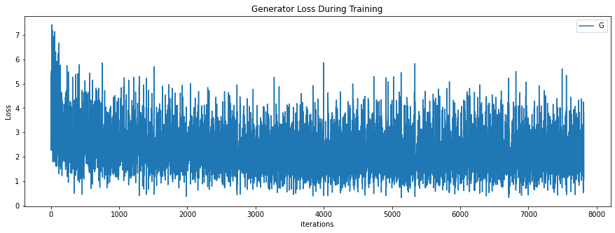

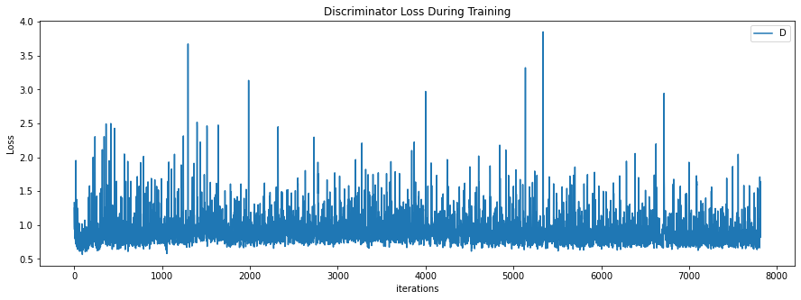

```python
import matplotlib.pyplot as plt
plt.figure(figsize=(15,5))
plt.title("Generator Loss During Training")
plt.plot(G_losses,label="G")
plt.xlabel("iterations")
plt.ylabel("Loss")
plt.legend()
plt.show()
plt.figure(figsize=(15,5))
plt.title("Discriminator Loss During Training")
plt.plot(D_losses,label="D")
plt.xlabel("iterations")
plt.ylabel("Loss")
plt.legend()
plt.show()
```

```python
import numpy as np
```

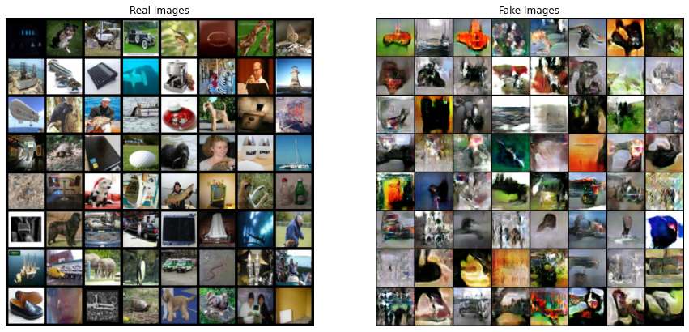

```python
# Grab a batch of real images from the dataloader
real_batch = next(iter(trainloader))

# Plot the real images
plt.figure(figsize=(15,15))
plt.subplot(1,2,1)
plt.axis("off")
plt.title("Real Images")
plt.imshow(np.transpose(vutils.make_grid(real_batch.to(device)[:64], padding=5, normalize=True).cpu(),(1,2,0)))

# Plot the fake images from the last epoch
plt.subplot(1,2,2)
plt.axis("off")
plt.title("Fake Images")
plt.imshow(np.transpose(img_list[-1],(1,2,0)))
plt.show()
```

```python
try:
    from google.colab import drive
    torch.save(best_D_state_dict, '/content/drive/My Drive/discriminator_weights.pth')
except:
    torch.save(best_D_state_dict, 'discriminator_weights.pth')
```

## Task 4. Transfer Learning Experiments

Perform the following set of transfer learning experiments:

- **Fixed Features:** Initialize the first $k$ layers with the parameters learned in Task 3 and randomly initialize the layers of the classification head. *Train only the layers of the classification head!*
- **Finetuned Features:** Initialize the first $k$ layers with the parameters learned in Task 3 and randomly initialize the layers of the classification head. *Train all the layers!*
- **Random Features Fixed:** Randomly initialize all the layers for the classification task (do not use parameters learned in Task 3). *Train only the layers of the classification head!*
- **Random Features Finetuned:** Randomly initialize all the layers for the classification task (do not use parameters learned in Task 3). *Train all the layers!*

Evaluate each of those models on the validation set and summarize the results in a Table.

Note: I didn't explicitly initialized the layers randomly as asked because they are randomly initialized by default.

Results summary on validation set:

| Fixed Features | Finetuned Features | Random Features Fixed | Random Features Finetuned |
| --- | --- | --- | --- |
| 11.5% | 11.15% | 6.3% | 9.5% |

```python
def train_epoch(model, train_dataloader, optimizer, loss_fn):
    losses = []
    correct_predictions = 0

    # Iterate mini batches over training dataset
    for images, labels in tqdm(train_dataloader):
        images = images.to(device)
        labels = labels.to(device)
        # Run predictions
        output = model(images)
        # Set gradients to zero
        optimizer.zero_grad()
        # Compute loss
        loss = loss_fn(output, labels)
        # Backpropagate (compute gradients)
        loss.backward()
        # Make an optimization step (update parameters)
        optimizer.step()
        # Log metrics
        losses.append(loss.item())
        predicted_labels = output.argmax(dim=1)
        correct_predictions += (predicted_labels == labels).sum().item()
    # Return loss values for each iteration and accuracy
    mean_loss = np.array(losses).mean()
    accuracy = 100.0 * correct_predictions / len(train_dataloader.dataset)
    return mean_loss, accuracy

def evaluate(model, dataloader, loss_fn):
    losses = []
    correct_predictions = 0
    # Iterate mini batches over validation dataset
    with torch.no_grad():
        for images, labels in dataloader:
            images = images.to(device)
            labels = labels.to(device)
            # Run predictions
            output = model(images)
            # Compute loss
            loss = loss_fn(output, labels)
            # Save metrics
            losses.append(loss.item())
            predicted_labels = output.argmax(dim=1)
            correct_predictions += (predicted_labels == labels).sum().item()
    # Return mean loss and accuracy
    mean_loss = np.array(losses).mean()
    accuracy = 100.0 * correct_predictions / len(dataloader.dataset)
    return mean_loss, accuracy
```

```python
%matplotlib inline
import matplotlib.pyplot as plt

def plot(n_epochs, train_losses, val_losses, train_accuracies, val_accuracies):
    plt.figure(figsize=(15,6))

    legend_loss=[]

    plt.plot(np.arange(n_epochs), train_losses,'r')
    legend_loss.append('train_loss')

    plt.plot(np.arange(n_epochs), val_losses,'g')
    legend_loss.append('val_loss')

    plt.legend(legend_loss)

    plt.xlabel('epoch')
    plt.ylabel('loss value')
    plt.title('Train/val loss');

    plt.figure(figsize=(15,6))

    legend_acc=[]

    plt.plot(np.arange(n_epochs), train_accuracies,'r')
    legend_acc.append('train_acc')

    plt.plot(np.arange(n_epochs),val_accuracies, 'g')
    legend_acc.append('val_acc')
    plt.grid()
    plt.legend(legend_acc)
    plt.xlabel('epoch')
    plt.ylabel('accuracy [%]')
    plt.title('Train/val accuracy');
```

```python
def train_plot_return_best(model, train_dataloader, val_dataloader, optimizer, n_epochs, loss_function):
    max_acc=0
    best_model_state_dict=None
    # We will monitor loss functions as the training progresses
    train_losses = []
    val_losses = []
    train_accuracies = []
    val_accuracies = []

    scheduler = torch.optim.lr_scheduler.ReduceLROnPlateau(optimizer, 'max',factor=0.2,patience=4,threshold=0.25,verbose=True)

    # Run training for n_epochs
    for epoch in tqdm(range(n_epochs)):
        model.train()
        train_loss, train_accuracy = train_epoch(model, train_dataloader, optimizer, loss_fn)
        model.eval()
        val_loss, val_accuracy = evaluate(model, val_dataloader, loss_fn)
        if val_accuracy > max_acc:
            max_acc=val_accuracy
            best_model_state_dict=copy.deepcopy(model.state_dict())
        scheduler.step(val_accuracy)
        train_losses.append(train_loss)
        val_losses.append(val_loss)
        train_accuracies.append(train_accuracy)
        val_accuracies.append(val_accuracy)
        print('Epoch {}/{}: train_loss: {:.4f}, train_accuracy: {:.4f}, val_loss: {:.4f}, val_accuracy: {:.4f}'.format(epoch+1, n_epochs,
                                                                                                    train_losses[-1],
                                                                                                    train_accuracies[-1],
                                                                                                    val_losses[-1],
                                                                                                    val_accuracies[-1]))
    plot(n_epochs,train_losses, val_losses, train_accuracies, val_accuracies)
    model_best=ConvNet()
    model_best=model_best.to(device)
    model_best.load_state_dict(best_model_state_dict)
    return model_best
```

```python
from torch.utils.data import DataLoader
batch_size=64
train_dataloader = DataLoader(train_set, batch_size=batch_size, shuffle=True, num_workers=8,pin_memory=True)
val_dataloader = DataLoader(val_set, batch_size=batch_size, shuffle=False, num_workers=8,pin_memory=True)
```

```python
try:
    from google.colab import drive
    pretrained_dict=torch.load('/content/drive/My Drive/discriminator_weights.pth')
except:
    pretrained_dict=torch.load('discriminator_weights.pth')
```

```python
def init_first_layers(model,pretrained_dict):
    model_dict = model.state_dict()

    # 1. filter out unnecessary keys
    pretrained_dict = {k: v for k, v in pretrained_dict.items() if k in model_dict and v.size()==model_dict[k].size() }
    # 2. overwrite entries in the existing state dict
    model_dict.update(pretrained_dict)
    # 3. load the new state dict
    model.load_state_dict(model_dict)

    return model
```

```python
def freeze_layers(model):
    # Freeze all layers except the classification head
    for layer in model.conv_layers:
        try:
            layer.weight.requires_grad = False
        except AttributeError:
            print(layer)

    return model
```

```python
def create_fixed_features_model():
    fixed_features_cnn=ConvNet()
    fixed_features_cnn=init_first_layers(fixed_features_cnn,pretrained_dict)
    fixed_features_cnn=freeze_layers(fixed_features_cnn)
    fixed_features_cnn =fixed_features_cnn.to(device)

    return fixed_features_cnn
```

```
LeakyReLU(negative_slope=0.2, inplace=True)
LeakyReLU(negative_slope=0.2, inplace=True)
LeakyReLU(negative_slope=0.2, inplace=True)
LeakyReLU(negative_slope=0.2, inplace=True)
LeakyReLU(negative_slope=0.2, inplace=True)
LeakyReLU(negative_slope=0.2, inplace=True)
```

```
Epoch    13: reducing learning rate of group 0 to 2.0000e-03.
```

```
Epoch    18: reducing learning rate of group 0 to 4.0000e-04.
```

```
Epoch    23: reducing learning rate of group 0 to 8.0000e-05.
```

```
Epoch    28: reducing learning rate of group 0 to 1.6000e-05.
```

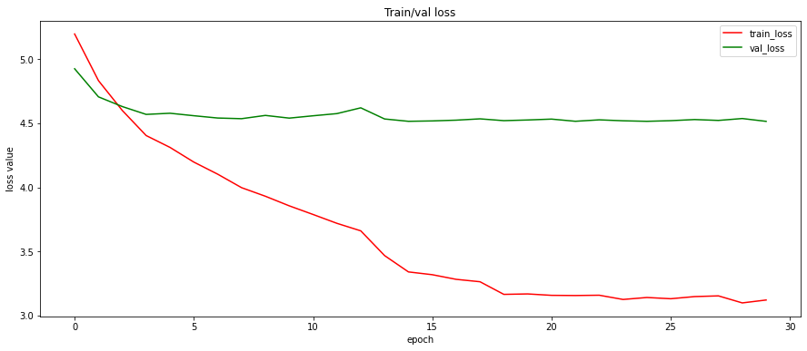

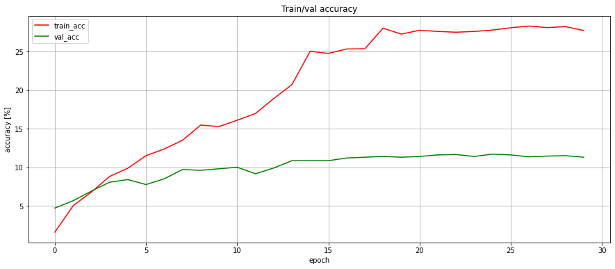

```python
lr_001=0.01
n_epochs=30
loss_fn = nn.CrossEntropyLoss()

fixed_features_cnn=create_fixed_features_model()

fixed_features_cnn_optimizer=torch.optim.SGD(filter(lambda p: p.requires_grad, fixed_features_cnn.parameters()),lr=lr_001,momentum=0.9,nesterov=True)

fixed_features_cnn=train_plot_return_best(fixed_features_cnn, train_dataloader, val_dataloader, fixed_features_cnn_optimizer, n_epochs=n_epochs, loss_function=loss_fn)
```

```python
def create_finetuned_features_cnn():
    finetuned_features_cnn=ConvNet()
    finetuned_features_cnn=init_first_layers(finetuned_features_cnn,pretrained_dict)
    finetuned_features_cnn =finetuned_features_cnn.to(device)
    return finetuned_features_cnn
```

```
Epoch    10: reducing learning rate of group 0 to 2.0000e-03.
```

```
Epoch    16: reducing learning rate of group 0 to 4.0000e-04.
```

```
Epoch    21: reducing learning rate of group 0 to 8.0000e-05.
```

```
Epoch    26: reducing learning rate of group 0 to 1.6000e-05.
```

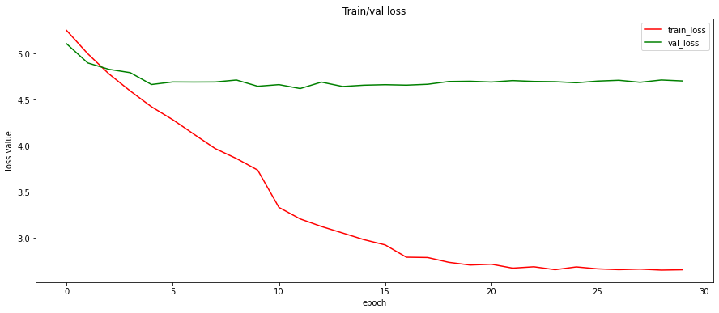

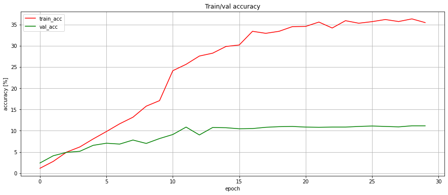

```python
finetuned_features_cnn=create_finetuned_features_cnn()
finetuned_features_cnn_optimizer=torch.optim.SGD( finetuned_features_cnn.parameters(),lr=lr_001,momentum=0.9,nesterov=True)

finetuned_features_cnn=train_plot_return_best(finetuned_features_cnn, train_dataloader, val_dataloader, finetuned_features_cnn_optimizer, n_epochs=n_epochs, loss_function=loss_fn)
```

```python
def create_random_features_fixed_cnn():
    random_features_fixed_cnn=ConvNet()
    random_features_fixed_cnn=freeze_layers(random_features_fixed_cnn)
    random_features_fixed_cnn =random_features_fixed_cnn.to(device)

    return random_features_fixed_cnn
```

```
LeakyReLU(negative_slope=0.2, inplace=True)
LeakyReLU(negative_slope=0.2, inplace=True)
LeakyReLU(negative_slope=0.2, inplace=True)
LeakyReLU(negative_slope=0.2, inplace=True)
LeakyReLU(negative_slope=0.2, inplace=True)
LeakyReLU(negative_slope=0.2, inplace=True)
```

```
Epoch    15: reducing learning rate of group 0 to 2.0000e-03.
```

```
Epoch    23: reducing learning rate of group 0 to 4.0000e-04.
```

```
Epoch    28: reducing learning rate of group 0 to 8.0000e-05.
```

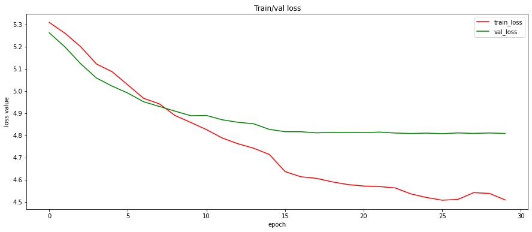

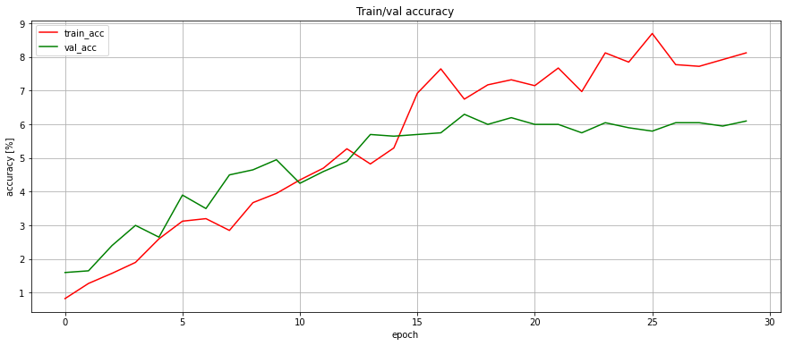

```python
random_features_fixed_cnn=create_random_features_fixed_cnn()

random_features_fixed_cnn_optimizer=torch.optim.SGD(filter(lambda p: p.requires_grad, random_features_fixed_cnn.parameters()),lr=lr_001,momentum=0.9,nesterov=True)

random_features_fixed_cnn=train_plot_return_best(random_features_fixed_cnn, train_dataloader, val_dataloader, random_features_fixed_cnn_optimizer, n_epochs=n_epochs, loss_function=loss_fn)
```

```python
def create_random_features_finetuned_cnn():
    random_features_finetuned_cnn=ConvNet()
    random_features_finetuned_cnn =random_features_finetuned_cnn.to(device)

    return random_features_finetuned_cnn
```

```
Epoch    15: reducing learning rate of group 0 to 2.0000e-03.
```

```
Epoch    21: reducing learning rate of group 0 to 4.0000e-04.
```

```
Epoch    26: reducing learning rate of group 0 to 8.0000e-05.
```

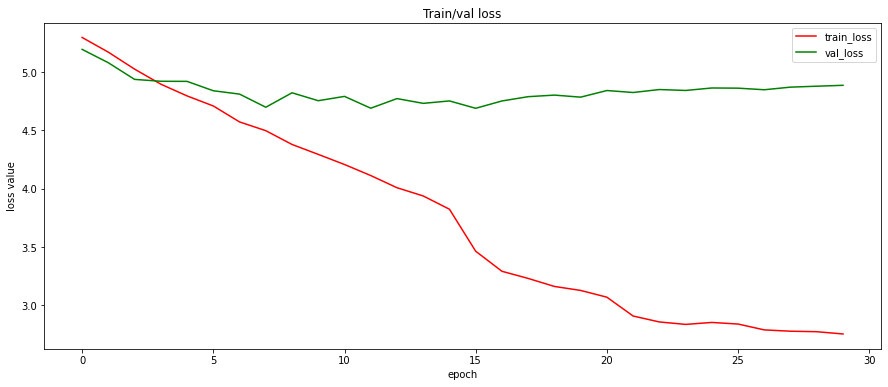

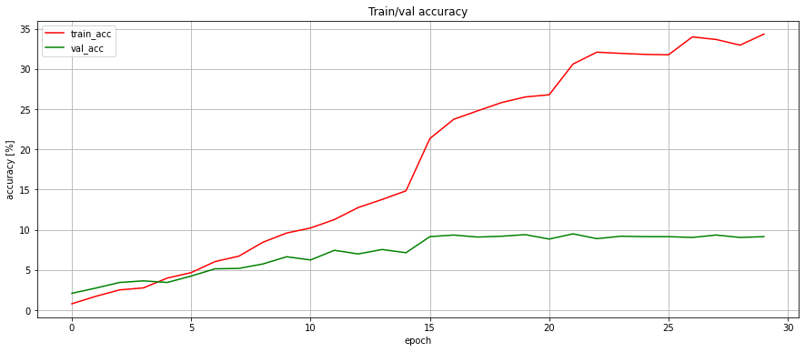

```python
random_features_finetuned_cnn=create_random_features_finetuned_cnn()

random_features_finetuned_cnn_optimizer=torch.optim.SGD(random_features_finetuned_cnn.parameters(),lr=lr_001,momentum=0.9,nesterov=True)

random_features_finetuned_cnn=train_plot_return_best(random_features_finetuned_cnn, train_dataloader, val_dataloader, random_features_finetuned_cnn_optimizer, n_epochs=n_epochs, loss_function=loss_fn)
```

## Task 5. Competition time!

Read the images from "data/test" folder. There are no labels for these images. Run your best model (from Task 4) on these images and save the image IDs (names) and predicted label in a file LastName.csv. You will receive a link via email to upload the CSV file to an online system which will give you the score of your model on the held-out test set. Top 5 students will obtain bonus points.

*Provide a short description of the model you used for the Kaggle submission.*

I trained a GAN and then used the discriminator to transfer the features to the classificator. For the classificator/discriminator architecture I used pytorch's DCGAN tutorial and modified it to look a little bit like VGG. The Kaggle submission was made with the fixed features model because it achieved the best accuracy on the validation set.

```python
def test(model,dataloader):
    model.eval()
    y_pred=np.array([],dtype=int)

    with torch.no_grad():
        for images in dataloader:
            images = images.to(device)
            output = model(images)
            for y in output.argmax(1).cpu().numpy():
                y_pred=np.append(y_pred,y)

    return y_pred
```

```python
class TestDataset(torch.utils.data.Dataset):
    def __init__(self, data):
        self.data = data

    def __getitem__(self, index):
        return self.data[index]

    def __len__(self):
        return len(self.data)
```

```python
test_files = glob.glob(test_dir+'/*.jpg')
images=[]
ids=[]
for file in tqdm(test_files):
    ids.append(file.split('/')[-1].split('.')[0])
    temp = Image.open(file)
    keep = temp.copy()
    images.append(transform(keep))
    temp.close()
```

```python
test_dataset=TestDataset(images)
test_loader = torch.utils.data.DataLoader(test_dataset, batch_size=64)
```

```python
predictions=dict(zip(ids,test(fixed_features_cnn,test_loader)))
```

```python
with open('Goloviatinski.csv', 'w') as f:
    f.write('id,label\n')
    for id, pred in predictions.items():
        f.write(f'{id},{pred}\n')
```